# Fall 2021 - Math 421 - Midterm

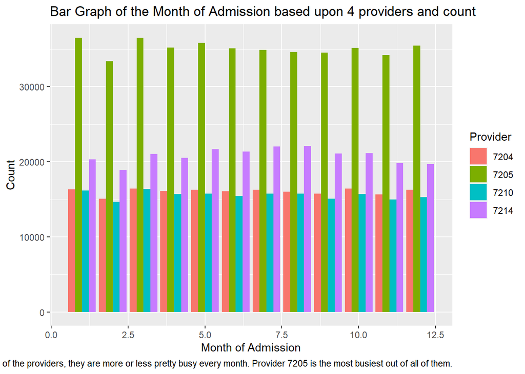

```r
df %>% filter(provider == 7205| provider == 7214| provider == 7204|provider == 7210) %>% ggplot()+
  geom_bar(mapping=aes(x=moa, fill=factor(provider)), position='dodge')+
  labs(x='Month of Admission',
       y = 'Count',
       fill ='Provider',
       title = 'Bar Graph of the Month of Admission based upon 4 providers and count',
       caption = 'There are technically no popular months for any of the providers, they are more or less pretty busy every month. Provider 7205 is the most busiest out of all of them.')
```

I wanted to see how popular all of the providers were with a length of stay under 50 and any total amount due for the patient.

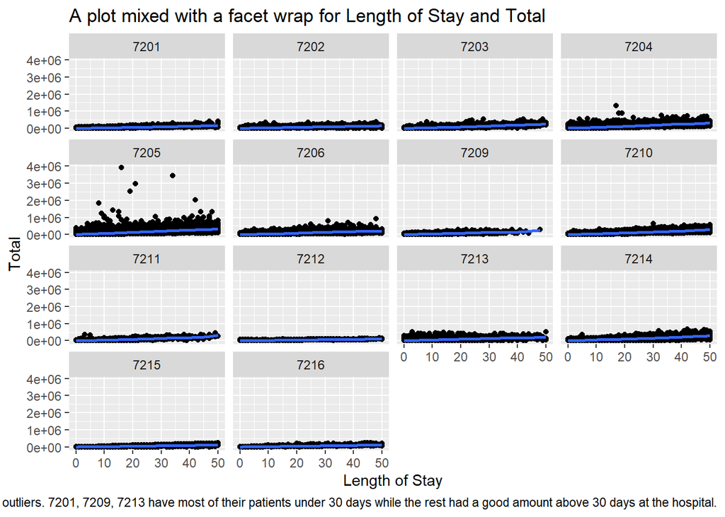

```r
df %>% filter(los <=50) %>%
  ggplot(mapping=aes(x=los, y=tot))+
  geom_point()+
  geom_smooth()+
  facet_wrap(~provider)+
  labs(x='Length of Stay',
       y = 'Total',
       title = 'A plot mixed with a facet wrap for Length of Stay and Total', caption = 'Most of the providers have a very linear relationship when it comes how much they charge a certain customer, minus a very few outliers. 7201, 7209, 7213 have most of their patients under 30 days while the rest had a good amount above 30 days at the hospital.')
```

I filtered out just months of 9, 10, and 11 with a length of stay under 50 to see most of the data.

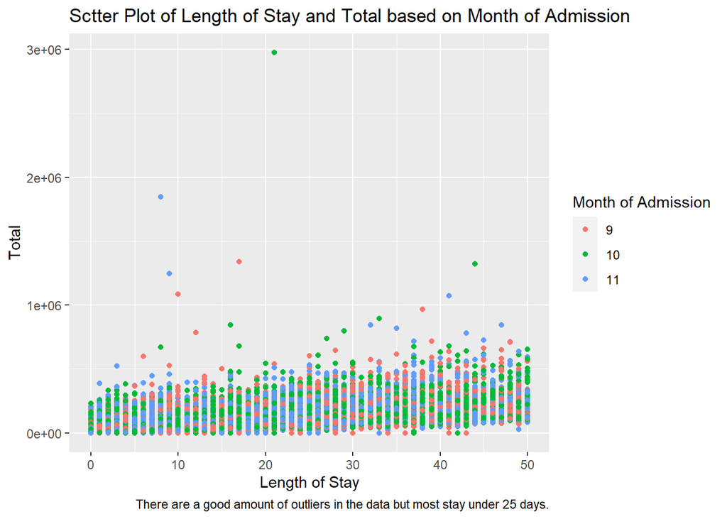

```r
#moa is 9,10, or 11
df %>% filter(moa==9 | moa==10 | moa==11) %>% filter(los <= 50) %>% ggplot()+
  geom_point(mapping = aes(x = los, y = tot, color = factor(moa)))+
  labs(x='Length of Stay',
       y = 'Total',
       color = 'Month of Admission',
       title = 'Sctter Plot of Length of Stay and Total based on Month of Admission',
       caption = 'There are a good amount of outliers in the data but most stay under 25 days.')
```

I just wanted to look at 3 providers: which are 7205, 7204, and 7214 with under a length of stay of 50 days.

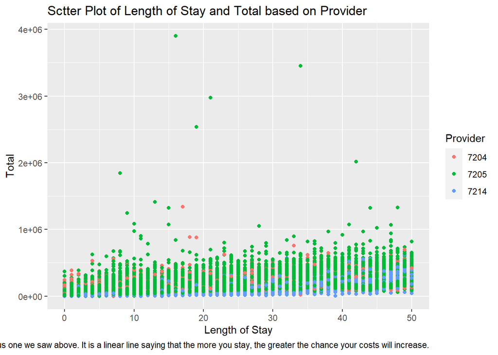

```r
df %>% filter(provider==7205 | provider==7204 | provider==7214) %>% filter(los <= 50) %>% ggplot()+
  geom_point(mapping = aes(x = los, y = tot, color = factor(provider)))+
  labs(x='Length of Stay',
       y = 'Total',
       color = 'Provider',
       title = 'Sctter Plot of Length of Stay and Total based on Provider',
       caption = 'There are a few outliers compared to the previous one we saw above. It is a linear line saying that the more you stay, the greater the chance your costs will increase.')
```

I wanted to see the average age of the patients based upon each month.

[figure not shown]

```r
df %>% group_by(moa) %>% summarise(average_age=mean(age)) %>%
  ggplot()+
  geom_col(mapping=aes(x=moa, y=average_age))+
  labs(x='Month of Admission',
       y = 'Average Age',
       title = 'Column chart of Month of Admission and Average Age',
       caption = 'Through out the months, the average age stays very consistent which is around 50 years old. ')
```

2. Make an animation plot.You should use the bar race.

I wanted to see what is the average age per month broken down by each provider. I wanted to see who has the oldest people on a consistent basis.

[figure not shown]

```r
d1 <- df %>% group_by(moa, provider) %>% summarise(mean = mean(age, na.rm=TRUE))
d2 <- d1 %>% group_by(moa) %>% mutate(rank=rank(-mean)) %>% ungroup()
d3 <- d2 %>% filter(rank <= 10)
a1 <- d3 %>% ggplot(aes(x=rank, y=mean, group=provider, fill=factor(provider), label=provider)) + geom_col()+
    geom_text(aes(y = mean, label = provider), hjust = 1.4)+
    coord_flip(clip = "off", expand = FALSE) +scale_x_reverse()+
    labs(title = 'Month {closest_state}', x='', y='Age', fill='provider')+
    theme(plot.title = element_text(hjust = 1, size = 22),
          axis.ticks.y = element_blank(),
          axis.text.y  = element_blank(), legend.position = "none") +
    transition_states(moa)+
    ease_aes("cubic-in-out")
animate(a1, nframes = 400)
```

3. Write a paragraph to summarize the section and give your comments on the results. This section gave me really good insight to my dataset, especially my continuous variables. My continuous variables had a lot of skewed data, specifically my length of stay and the total charge for each patient. Additionally, it allowed me to understand my other important variables that I wanted to understand more like provider, MOA, and campus. The one that gave me the best result was my animation because I think it was the most informational. It gave me the results on a per month basis for how much the average age changes, which I thought was really cool. The other graph that was helpful to me was believe or not the simplest one. It was the histogram where it counted up all the values for LOS and tot column. This was the most helpful because it allowed me to see the distribution of my continuous variables better than any other graph. With this in mind, those graphs made me create better looking graphs that had more detail added to them.

## III. Predictive Models

Continue with the data from part I. Use the follows as the target and input variables:

Target Variable: Create the target variable taking value of

- low if the total charge of a patient (tot) is smaller than the median of the total charge, and
- high otherwise.

Input Variables:

- “age”,“sex”,“raceethn”,“provider”,“moa”,“mod”,“admtype”,“campus”, ‘los’

```r
df5 <- df1 %>% filter(yod == 18) %>% select("tot","yod","age","sex","raceethn","provider","moa","mod","admtype","campus","los")

write_csv(df5, "final_midterm_part_3!1.csv")

pred_df <- read_csv("final_midterm_part_3!1.csv")

pred_df$tot <- cut(pred_df$tot,
                      breaks = c(-Inf, 13400, 37000,Inf),
                      labels=c('low','mid','high'))
table(pred_df$tot)
```

```
##
##   low   mid  high
## 32948 65773 32757
```

```r
#drop the rows with the null values
pred_df <- pred_df %>% drop_na(raceethn,admtype)
```

1. Use filter function to filter out rows where raceethn==’’ or admtype==’’. Make sure all the categorical variables are factor, numeric variables are numeric. Set Training : Testing Split = 10 : 90
2. Train a decision tree using rpart. Plot the decision tree. Plot the variable importance ranked by the tree.
3. Using caret for this question. Set Training Control to be: Use Cross-Validation of 5 folds across all models. Train & tune at least 3 different models (i.e. three different values for method= in the train function of caret). Plot the hyper-parameter tuning plots for each model.
4. Plot the comparison of the models in 3.
5. What is your final selection for the model? Test the accuracy of your final model on the test data.

```r
#import library
library(caret)
```

[figure not shown]

```r
#1
pred_df <- pred_df %>% filter(raceethn != ""| admtype != "")

drops <- "yod"
pred_df <- pred_df[ , !(names(pred_df) %in% drops)]

set.seed(00000)
splitIndex <- createDataPartition(pred_df$tot, p = .90,
                                  list = FALSE)
df_train <- pred_df[ splitIndex,]
df_test <- pred_df[-splitIndex,]

#2
library(rpart) #load the rpart package
# Create a tree
tree_model <- rpart(tot ~ ., data = df_train,
                 control = rpart.control(maxdepth = 3))
library(rattle)
fancyRpartPlot(tree_model)
```

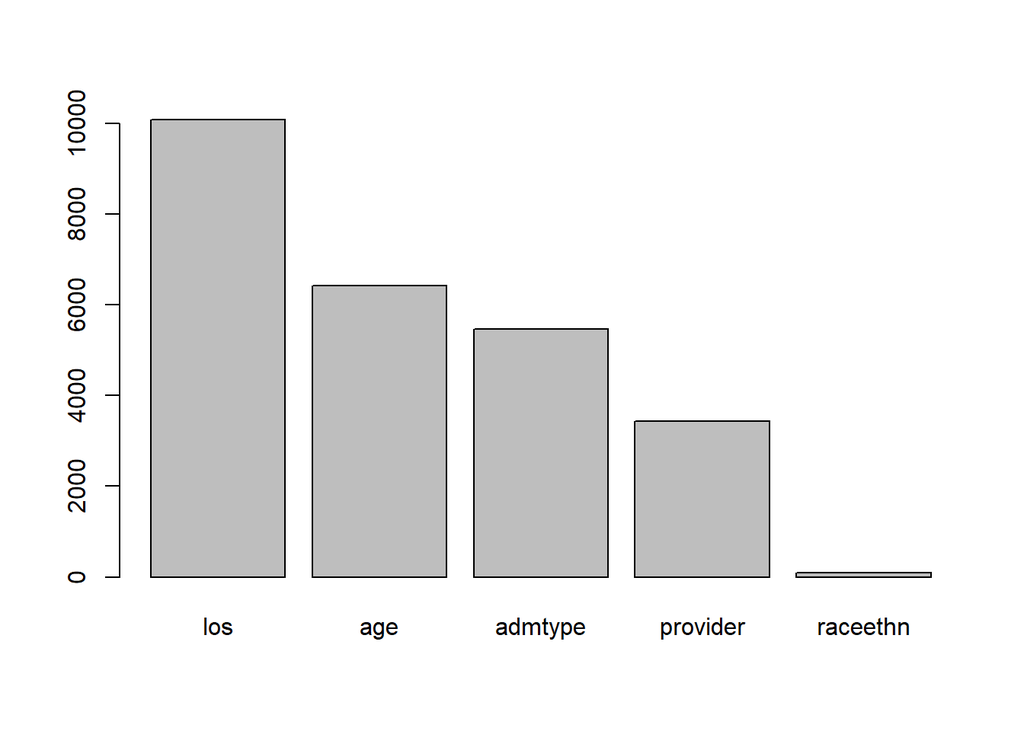

```r
barplot(tree_model$variable.importance)
```

```r
#3
trControl = trainControl(method = "cv",
                         number = 5)

tree <- train(tot~., data=df_train,
                                method = "rpart2",
                                trControl = trControl)

forest_ranger <- train(tot~., data=df_train,
                    method = "ranger",
                                trControl = trControl)
```

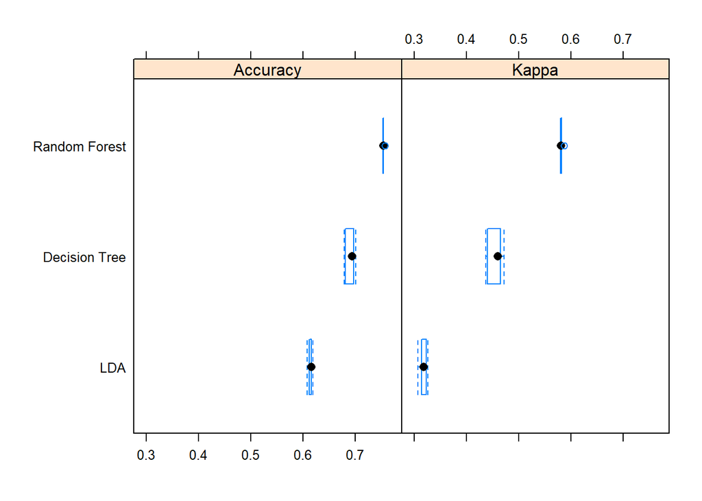

```r
lda <- train(tot~., data=df_train,
                                method = "lda",
                                trControl = trControl)

results <- resamples(list('Decision Tree' = tree,
                          'Random Forest' = forest_ranger,
                          'LDA'= lda))
#4
bwplot(results)
```

```r
#5 --> my final selection would be the Random Forest Model given the fact that it gave me the best result.
```

6. Create another target variable (binary), decide the input variables and redo 1 to 5.

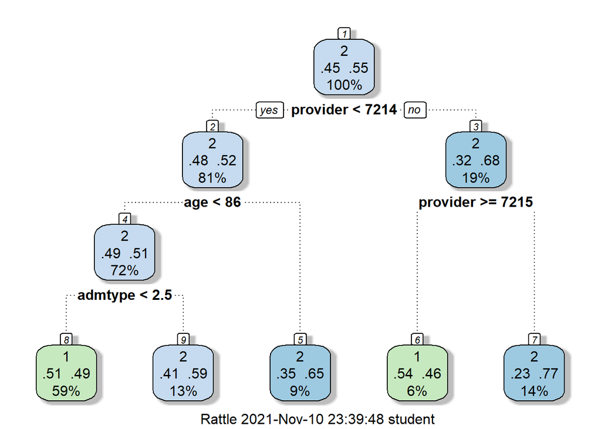

```r
sec_pred_df <- pred_df %>% filter(raceethn != ""| admtype != "")

drops <- "yod"
sec_pred_df <- sec_pred_df[ , !(names(sec_pred_df) %in% drops)]

sec_pred_df <- sec_pred_df %>% filter(sex == 1 | sex == 2)

sec_pred_df$sex <- factor(sec_pred_df$sex)

set.seed(00000)
splitIndex <- createDataPartition(sec_pred_df$tot, p = .90,
                                  list = FALSE)
df_train <- sec_pred_df[ splitIndex,]
df_test <- sec_pred_df[-splitIndex,]

#---------------------------------------

library(rpart) #load the rpart package
# Create a tree
tree_model <- rpart(sex ~ ., data = df_train,
                 control = rpart.control(maxdepth = 3))
library(rattle)
fancyRpartPlot(tree_model)
```

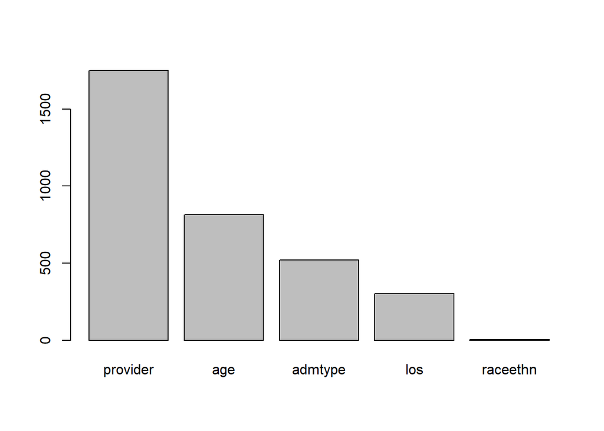

```r
barplot(tree_model$variable.importance)
```

```r
#---------------------------------------

trControl = trainControl(method = "cv",
                         number = 5)

tree <- train(sex~., data=df_train,
                                method = "rpart2",
                                trControl = trControl)

forest_ranger <- train(sex~., data=df_train,
                    method = "ranger",
                                trControl = trControl)
```

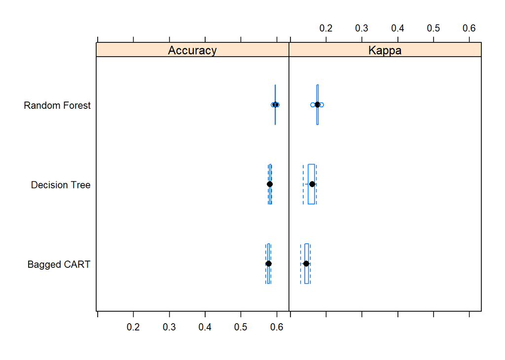

```r
treebag <- train(sex~., data=df_train,
                    method = "treebag",
                    trControl = trControl)
results <- resamples(list('Decision Tree' = tree,
                          'Random Forest' = forest_ranger,
                          'Bagged CART'= treebag))

bwplot(results)
```

```r
#---------------------------------------

#My final selection would be the Random Forest Model given the fact that it gave me the best result.
```

7. Write a paragraph to summarize the section and give your comments on the results. This gave me the most important variables to consider when looking at the dataset. For my decision tree, when predicting total charge for the stay, it looked like length of stay, age and admtype were the top three contributors. While for my particular target variable, which was sex: provider, age, and admtype were the top contributors to the model.